# 16S_vegan_tutorial

### 1.3 metadata table

Read in the metadata from an external file

```r
metadata <-  read.csv("16S_metadata.csv",row.names=1) # we make the first row (sample_name), the row.names
head(metadata)
```

```
##          habitat    DOCuM    TDNuM     Temp      Sal    pH
## St01_MN Mangrove 78.40417 5.207143 27.87090 38.99350 8.614
## St01_SG Seagrass 78.57083 3.828571 26.39420 40.19960 8.608
## St01_CR    Coral 74.69583 4.466429 26.28380 40.21680 8.606
## St01_SD     Sand 48.02917 4.278571 28.61670 40.55530 8.395
## St02_MN Mangrove 76.85417 6.254700 29.37162 37.90905 8.588
## St02_SG Seagrass 77.08750 4.278571 30.03010 38.27735 8.585
```

### 1.4 Check that the names on all tables match

Check the data to make sure the OTU table, TAX table and metadata files have all the same samples names and OTUs names

```r
nrow(OTU)==nrow(TAX) # TRUE we have the same number of OTUs in OTU and TAX
row.names(OTU) == row.names(TAX) # TRUE, and all the names match
names(OTU) == row.names(metadata) # sample names in OTU table match the sample names in the metadata
```

## 2. SEQUENCING DEPTH

### 2.1. Check sequencing depth (number of sequences per sample)

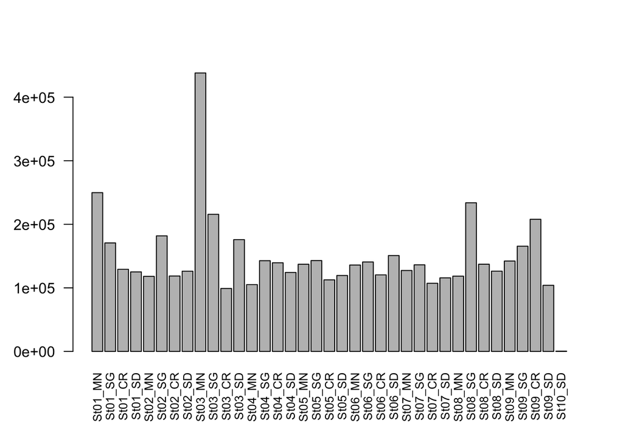

```r
# Check the different sequences obtained in each sample
seqs <- colSums(OTU) # sum all the number in each column (get the number of sequences per sample)
barplot(seqs,cex.names=0.8,las=2)
```

### 2.2 Remove samples with less than X reads

For example, check that they are all over 10000, but this number will depend on your data. It does not make sense to keep samples that are not reliable

```r
# check which samples have less than 10000 reads
colSums(OTU)<10000 # We have a bad sample!
```

```
## St01_MN St01_SG St01_CR St01_SD St02_MN St02_SG St02_CR St02_SD St03_MN
##   FALSE   FALSE   FALSE   FALSE   FALSE   FALSE   FALSE   FALSE   FALSE
## St03_SG St03_CR St03_SD St04_MN St04_SG St04_CR St04_SD St05_MN St05_SG
##   FALSE   FALSE   FALSE   FALSE   FALSE   FALSE   FALSE   FALSE   FALSE
## St05_CR St05_SD St06_MN St06_SG St06_CR St06_SD St07_MN St07_SG St07_CR
##   FALSE   FALSE   FALSE   FALSE   FALSE   FALSE   FALSE   FALSE   FALSE
## St07_SD St08_MN St08_SG St08_CR St08_SD St09_MN St09_SG St09_CR St09_SD
##   FALSE   FALSE   FALSE   FALSE   FALSE   FALSE   FALSE   FALSE   FALSE
## St10_SD
##    TRUE
```

```r
# If we have very low reads sample, we have to remove them.
# Identify the columns that have less than the desired number of counts
which(colSums(OTU)<10000)
```

```
## St10_SD
##      37
```

```r
# Delete the sample from the metadata table
bad <- which(row.names(metadata)==names(which(colSums(OTU)<10000))) # match to the sample name from the OTU table to the sample in the metadata
metadata <- metadata[-bad,] # delete bad samples and overwrite metadata table

# Delete the columns with low number of reads and overwrite the variable only with the good samples
OTU <- OTU[,colSums(OTU)>10000]
dim(OTU) # 994 rows x 36 columns. We lost one sample
```

```
## [1] 994  36
```

### 2.3 Transpose table

Vegan requieres a specific format of the data to calculate the alpha diversity and the distance matrices for beta diversity.

It requiers samples as rows and OTUs as columns. Basically, the opposite than what we have. We can fix this easily by trasnposing the table

```r
# Transpose table
OTUt <- t(sapply(OTU, as.numeric)) # the sapply() here is just to make sure that when we transpose, the data continue in numeric format.
OTUt[1:4,1:4]
```

```
##         [,1]  [,2]  [,3]  [,4]
## St01_MN 5811 43796 11141 14375
## St01_SG 8136  6968  3621  4650
## St01_CR 1179  1629  3302  3055
## St01_SD    0   167     0    25
```

```r
dim(OTUt) # 36 rows (samples) x 994 columns (OTUs)
```

```
## [1]  36 994
```

```r
# We lost the column names when transposing. We need to get them back
colnames(OTUt) <- row.names(OTU)
```

### 2.4. Rarefy samples to minimum number of reads (Optional)

There are different trends here, to rarefy or not to rarefy…philosophical question for you to investigate.

```r
# Find the sample with the minimum number of reads
minReads <- min(rowSums(OTUt))
minReads
```

```
## [1] 99067
```

```r
# make the aleatory sampling always the same
set.seed(1)

# Subsample each sample to the min number of sequences
OTUt_rarefy<-rrarefy(OTUt, minReads)

# Check that all samples have the same number of reads now
rowSums(OTUt_rarefy)
```

```
## St01_MN St01_SG St01_CR St01_SD St02_MN St02_SG St02_CR St02_SD St03_MN
##   99067   99067   99067   99067   99067   99067   99067   99067   99067
## St03_SG St03_CR St03_SD St04_MN St04_SG St04_CR St04_SD St05_MN St05_SG
##   99067   99067   99067   99067   99067   99067   99067   99067   99067
## St05_CR St05_SD St06_MN St06_SG St06_CR St06_SD St07_MN St07_SG St07_CR
##   99067   99067   99067   99067   99067   99067   99067   99067   99067
## St07_SD St08_MN St08_SG St08_CR St08_SD St09_MN St09_SG St09_CR St09_SD
##   99067   99067   99067   99067   99067   99067   99067   99067   99067
```

```r
# Remove OTUS that now are empty
OTUt_rarefy_nozero <- OTUt_rarefy[,colSums(OTUt_rarefy)>0]

OTUt_rarefy_nozero[1:4,1:4]
```

```
##         OTU_1 OTU_2 OTU_3 OTU_4
## St01_MN  2249 17553  4416  5682
## St01_SG  4718  4005  2090  2738
## St01_CR   913  1231  2522  2272
## St01_SD     0   127     0    18
```

```r
dim(OTUt_rarefy_nozero)
```

```
## [1]  36 994
```

```r
# You can save the rarefied table for next days
#write.csv(OTUt_rarefy_nozero,"OTUt_rarefied_nozero.csv",row.names=TRUE)
```

### 2.5. Rarefaction curve

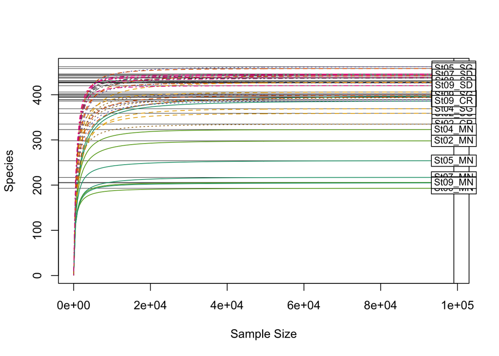

```r
# Check if samples saturate
# With the transposed table
rarecurve(OTUt_rarefy_nozero,step=500,sample=minReads,col=brewer.pal(n = 8, name = "Dark2"),lty=c(1:4),label=TRUE)
```